# shyshark_distribution_gis

2025-03-03

## Introduction

This GIS project is for an assignment for Jasper Slingsby’s module called GIS in R. The data I will be using is from iNaturalist. Where I will be looking at the distribution of Shysharks, along the Cape Peninsula. The species involved are Haploblepharus edwardsii (ssHe) and Haploblepharus pictus (ssHp). In addition, I used data on Poroderma africanum to compare distributions of these Shysharks.

## Setting CRAN

```r
options(repos = c(CRAN = "https://cloud.r-project.org"))
```

## Installing Packages

Below are the packages needed to start this project. Along the way I will add more.

```r
install.packages("tidyverse")
install.packages("rinat")
install.packages("sf")
```

## Reading in Libraries

I then read in the libraries I will need to start this project. Along the way I will read in more libraries.

```r
library(tidyverse)
library(rinat)
library(sf)
```

## Reading in the data from iNaturalist

I will be looking at the species Haploblepharus edwardsii, Haploblepharus pictus and Poroderma africanum. The View() and head() lines of code allows me to view the whole data set or just the first 6 rows.

```r
ssHp <- get_inat_obs( taxon_name = "Haploblepharus pictus",
                    bounds = c (-35, 18, -33.5, 18.5),
                    maxresults = 1000)
View(ssHp)
head(ssHp)
```

```
##         scientific_name                  datetime description
## 1 Haploblepharus pictus 2025-02-01 10:07:00 +0200
## 2 Haploblepharus pictus 2025-02-18 08:54:17 +0200
## 3 Haploblepharus pictus 2025-01-24 12:06:00 +0200
## 4 Haploblepharus pictus 2025-01-18 16:07:32 +0200
## 5 Haploblepharus pictus 2024-12-16 17:53:19 +0200
## 6 Haploblepharus pictus 2024-12-09 13:13:14 +0200
##                                      place_guess  latitude longitude tag_list
## 1                   City of Cape Town, ZA-WC, ZA -34.27672  18.48367
## 2 Water's Edge, Big Bay, Cape Town, South Africa -33.78883  18.45709
## 3         South Atlantic Ocean, Western Cape, ZA -34.20127  18.45721
## 4   Melkbosstrand, Cape Town, 7437, South Africa -33.71641  18.44782
## 5     Sunwood Drive, Cape Town, Western Cape, ZA -34.06298  18.43760
## 6              Smitswinkel Bay, Western Cape, ZA -34.26685  18.46780
##     common_name                                                url
```

[output cut: 62 more lines]

```r
ssHe <- get_inat_obs( taxon_name = "Haploblepharus edwardsii",
                      bounds = c (-35, 18, -33.5, 18.5),
                      maxresults = 1000)
View(ssHe)
head(ssHe)
```

```
##            scientific_name                  datetime description
## 1 Haploblepharus edwardsii 2024-10-17 18:45:00 +0200
## 2 Haploblepharus edwardsii 2024-09-29 18:47:00 +0200
## 3 Haploblepharus edwardsii 2024-09-29 18:42:00 +0200
## 4 Haploblepharus edwardsii 2024-09-29 18:39:00 +0200
## 5 Haploblepharus edwardsii 2024-12-07 10:56:00 +0200
## 6 Haploblepharus edwardsii 2024-12-06 00:00:00 +0200
##        place_guess  latitude longitude tag_list        common_name
## 1 Western Cape, ZA -34.27472  18.40197          Puffadder Shyshark
## 2 Western Cape, ZA -34.27802  18.44053          Puffadder Shyshark
## 3 Western Cape, ZA -34.22903  18.45306          Puffadder Shyshark
## 4 Western Cape, ZA -34.25303  18.49373          Puffadder Shyshark
## 5 Western Cape, ZA -34.26206  18.43907          Puffadder Shyshark
## 6 Western Cape, ZA -34.22826  18.47491          Puffadder Shyshark
##                                                  url
```

[output cut: 62 more lines]

```r
ssPa <- get_inat_obs( taxon_name = "Poroderma africanum",
                      bounds = c (-35, 18, -33.5, 18.5),
                      maxresults = 1000)
View(ssPa)
head(ssPa)
```

```
##       scientific_name                  datetime description
## 1 Poroderma africanum 2025-01-24 11:30:00 +0200
## 2 Poroderma africanum 2024-12-09 13:19:00 +0200
## 3 Poroderma africanum 2024-03-09 12:11:00 +0200
## 4 Poroderma africanum 2024-03-09 12:04:00 +0200
## 5 Poroderma africanum 2024-10-19 09:56:00 +0200
## 6 Poroderma africanum 2024-10-17 17:57:22 +0200
##                              place_guess  latitude longitude tag_list
## 1 South Atlantic Ocean, Western Cape, ZA -34.20135  18.45691
## 2           Simonsbaai, Western Cape, ZA -34.18695  18.42803
## 3           City of Cape Town, ZA-WC, ZA -34.18701  18.42777
## 4           City of Cape Town, ZA-WC, ZA -34.18789  18.42721
## 5           City of Cape Town, ZA-WC, ZA -34.20029  18.45676
## 6   Muizenberg Beach, Muizenberg, WC, ZA -34.10660  18.47482
##    common_name                                                url
```

[output cut: 62 more lines]

## Filtering Returned Observations

This narrows down the data based on specific conditions or criteria. I want the data to only be research grade and I want to exclude cultivated records (e.g. data points from aquariums etc.)

```r
ssHp <- ssHp %>% filter(positional_accuracy<46 &
                      latitude<0 &
                      !is.na(latitude) &
                      captive_cultivated == "false" &
                      quality_grade == "research")

class(ssHp)
```

```
## [1] "data.frame"
```

```r
ssHe <- ssHe %>% filter(positional_accuracy<46 &
                          latitude<0 &
                          !is.na(latitude) &
                          captive_cultivated == "false" &
                          quality_grade == "research")

class(ssHe)
```

```
## [1] "data.frame"
```

```r
ssPa <- ssPa %>% filter(positional_accuracy<46 &
                          latitude<0 &
                          !is.na(latitude) &
                          captive_cultivated == "false" &
                          quality_grade == "research")

class(ssPa)
```

```
## [1] "data.frame"
```

## Making the data frame into a spatial object

```r
ssHe <- st_as_sf(ssHe, coords = c("longitude", "latitude"), crs = 4326)
print(ssHe)
```

```
## Simple feature collection with 121 features and 35 fields
## Geometry type: POINT
## Dimension:     XY
## Bounding box:  xmin: 18.3809 ymin: -34.39451 xmax: 18.49864 ymax: -34.00119
## Geodetic CRS:  WGS 84
## First 10 features:
##             scientific_name                  datetime description
## 1  Haploblepharus edwardsii 2024-10-17 18:45:00 +0200
## 2  Haploblepharus edwardsii 2024-09-29 18:47:00 +0200
## 3  Haploblepharus edwardsii 2024-09-29 18:42:00 +0200
## 4  Haploblepharus edwardsii 2024-09-29 18:39:00 +0200
## 5  Haploblepharus edwardsii 2024-12-07 10:56:00 +0200
## 6  Haploblepharus edwardsii 2024-12-06 00:00:00 +0200
## 7  Haploblepharus edwardsii 2024-09-16 11:47:00 +0200
## 8  Haploblepharus edwardsii 2024-09-16 11:33:00 +0200
```

[output cut: 112 more lines]

```r
class(ssHe)
```

```
## [1] "sf"         "data.frame"
```

```r
ssHp <- st_as_sf(ssHp, coords = c("longitude", "latitude"), crs = 4326)
print(ssHp)
```

```
## Simple feature collection with 98 features and 35 fields
## Geometry type: POINT
## Dimension:     XY
## Bounding box:  xmin: 18.3117 ymin: -34.39 xmax: 18.4942 ymax: -33.8692
## Geodetic CRS:  WGS 84
## First 10 features:
##          scientific_name                  datetime description
## 1  Haploblepharus pictus 2025-01-24 12:06:00 +0200
## 2  Haploblepharus pictus 2024-10-17 18:37:00 +0200
## 3  Haploblepharus pictus 2024-10-11 18:22:00 +0200
## 4  Haploblepharus pictus 2024-12-13 11:38:00 +0200
## 5  Haploblepharus pictus 2024-11-16 10:48:00 +0200
## 6  Haploblepharus pictus 2024-03-09 12:40:00 +0200
## 7  Haploblepharus pictus 2024-03-09 11:51:00 +0200
## 8  Haploblepharus pictus 2024-03-09 11:50:00 +0200
```

[output cut: 123 more lines]

```r
class(ssHp)
```

```
## [1] "sf"         "data.frame"
```

```r
ssPa <- st_as_sf(ssPa, coords = c("longitude", "latitude"), crs = 4326)
print(ssPa)
```

```
## Simple feature collection with 89 features and 35 fields
## Geometry type: POINT
## Dimension:     XY
## Bounding box:  xmin: 18.3023 ymin: -34.2748 xmax: 18.4844 ymax: -34.0394
## Geodetic CRS:  WGS 84
## First 10 features:
##        scientific_name                  datetime
## 1  Poroderma africanum 2025-01-24 11:30:00 +0200
## 2  Poroderma africanum 2024-12-09 13:19:00 +0200
## 3  Poroderma africanum 2024-03-09 12:11:00 +0200
## 4  Poroderma africanum 2024-03-09 12:04:00 +0200
## 5  Poroderma africanum 2024-10-19 09:56:00 +0200
## 6  Poroderma africanum 2024-09-12 20:41:29 +0200
## 7  Poroderma africanum 2024-08-31 10:42:00 +0200
## 8  Poroderma africanum 2024-07-09 15:33:31 +0200
```

[output cut: 134 more lines]

```r
class(ssPa)
```

```
## [1] "sf"         "data.frame"
```

```r
# Should return "EPSG: 4326" (double checking that the EPSG is correct)
st_crs(ssHe)
```

```
## Coordinate Reference System:
##   User input: EPSG:4326
##   wkt:
## GEOGCRS["WGS 84",
##     ENSEMBLE["World Geodetic System 1984 ensemble",
##         MEMBER["World Geodetic System 1984 (Transit)"],
##         MEMBER["World Geodetic System 1984 (G730)"],
##         MEMBER["World Geodetic System 1984 (G873)"],
##         MEMBER["World Geodetic System 1984 (G1150)"],
##         MEMBER["World Geodetic System 1984 (G1674)"],
##         MEMBER["World Geodetic System 1984 (G1762)"],
##         MEMBER["World Geodetic System 1984 (G2139)"],
##         MEMBER["World Geodetic System 1984 (G2296)"],
##         ELLIPSOID["WGS 84",6378137,298.257223563,
##             LENGTHUNIT["metre",1]],
##         ENSEMBLEACCURACY[2.0]],
##     PRIMEM["Greenwich",0,
##         ANGLEUNIT["degree",0.0174532925199433]],
##     CS[ellipsoidal,2],
##         AXIS["geodetic latitude (Lat)",north,
##             ORDER[1],
##             ANGLEUNIT["degree",0.0174532925199433]],
##         AXIS["geodetic longitude (Lon)",east,
##             ORDER[2],
##             ANGLEUNIT["degree",0.0174532925199433]],
##     USAGE[
##         SCOPE["Horizontal component of 3D system."],
##         AREA["World."],
##         BBOX[-90,-180,90,180]],
##     ID["EPSG",4326]]
```

```r
names(ssHe)
```

```
##  [1] "scientific_name"                  "datetime"
##  [3] "description"                      "place_guess"
##  [5] "tag_list"                         "common_name"
##  [7] "url"                              "image_url"
##  [9] "user_login"                       "id"
## [11] "species_guess"                    "iconic_taxon_name"
## [13] "taxon_id"                         "num_identification_agreements"
## [15] "num_identification_disagreements" "observed_on_string"
## [17] "observed_on"                      "time_observed_at"
## [19] "time_zone"                        "positional_accuracy"
## [21] "public_positional_accuracy"       "geoprivacy"
## [23] "taxon_geoprivacy"                 "coordinates_obscured"
## [25] "positioning_method"               "positioning_device"
## [27] "user_id"                          "user_name"
## [29] "created_at"                       "updated_at"
## [31] "quality_grade"                    "license"
## [33] "sound_url"                        "oauth_application_id"
## [35] "captive_cultivated"               "geometry"
```

```r
st_crs(ssHp)
```

```
## Coordinate Reference System:
##   User input: EPSG:4326
##   wkt:
## GEOGCRS["WGS 84",
##     ENSEMBLE["World Geodetic System 1984 ensemble",
##         MEMBER["World Geodetic System 1984 (Transit)"],
##         MEMBER["World Geodetic System 1984 (G730)"],
##         MEMBER["World Geodetic System 1984 (G873)"],
##         MEMBER["World Geodetic System 1984 (G1150)"],
##         MEMBER["World Geodetic System 1984 (G1674)"],
##         MEMBER["World Geodetic System 1984 (G1762)"],
##         MEMBER["World Geodetic System 1984 (G2139)"],
##         MEMBER["World Geodetic System 1984 (G2296)"],
##         ELLIPSOID["WGS 84",6378137,298.257223563,
##             LENGTHUNIT["metre",1]],
##         ENSEMBLEACCURACY[2.0]],
##     PRIMEM["Greenwich",0,
##         ANGLEUNIT["degree",0.0174532925199433]],
##     CS[ellipsoidal,2],
##         AXIS["geodetic latitude (Lat)",north,
##             ORDER[1],
##             ANGLEUNIT["degree",0.0174532925199433]],
##         AXIS["geodetic longitude (Lon)",east,
##             ORDER[2],
##             ANGLEUNIT["degree",0.0174532925199433]],
##     USAGE[
##         SCOPE["Horizontal component of 3D system."],
##         AREA["World."],
##         BBOX[-90,-180,90,180]],
##     ID["EPSG",4326]]
```

```r
names(ssHp)
```

```
##  [1] "scientific_name"                  "datetime"
##  [3] "description"                      "place_guess"
##  [5] "tag_list"                         "common_name"
##  [7] "url"                              "image_url"
##  [9] "user_login"                       "id"
## [11] "species_guess"                    "iconic_taxon_name"
## [13] "taxon_id"                         "num_identification_agreements"
## [15] "num_identification_disagreements" "observed_on_string"
## [17] "observed_on"                      "time_observed_at"
## [19] "time_zone"                        "positional_accuracy"
## [21] "public_positional_accuracy"       "geoprivacy"
## [23] "taxon_geoprivacy"                 "coordinates_obscured"
## [25] "positioning_method"               "positioning_device"
## [27] "user_id"                          "user_name"
## [29] "created_at"                       "updated_at"
## [31] "quality_grade"                    "license"
## [33] "sound_url"                        "oauth_application_id"
## [35] "captive_cultivated"               "geometry"
```

```r
st_crs(ssPa)
```

```
## Coordinate Reference System:
##   User input: EPSG:4326
##   wkt:
## GEOGCRS["WGS 84",
##     ENSEMBLE["World Geodetic System 1984 ensemble",
##         MEMBER["World Geodetic System 1984 (Transit)"],
##         MEMBER["World Geodetic System 1984 (G730)"],
##         MEMBER["World Geodetic System 1984 (G873)"],
##         MEMBER["World Geodetic System 1984 (G1150)"],
##         MEMBER["World Geodetic System 1984 (G1674)"],
##         MEMBER["World Geodetic System 1984 (G1762)"],
##         MEMBER["World Geodetic System 1984 (G2139)"],
##         MEMBER["World Geodetic System 1984 (G2296)"],
##         ELLIPSOID["WGS 84",6378137,298.257223563,
##             LENGTHUNIT["metre",1]],
##         ENSEMBLEACCURACY[2.0]],
##     PRIMEM["Greenwich",0,
##         ANGLEUNIT["degree",0.0174532925199433]],
##     CS[ellipsoidal,2],
##         AXIS["geodetic latitude (Lat)",north,
##             ORDER[1],
##             ANGLEUNIT["degree",0.0174532925199433]],
##         AXIS["geodetic longitude (Lon)",east,
##             ORDER[2],
##             ANGLEUNIT["degree",0.0174532925199433]],
##     USAGE[
##         SCOPE["Horizontal component of 3D system."],
##         AREA["World."],
##         BBOX[-90,-180,90,180]],
##     ID["EPSG",4326]]
```

```r
names(ssPa)
```

```
##  [1] "scientific_name"                  "datetime"
##  [3] "description"                      "place_guess"
##  [5] "tag_list"                         "common_name"
##  [7] "url"                              "image_url"
##  [9] "user_login"                       "id"
## [11] "species_guess"                    "iconic_taxon_name"
## [13] "taxon_id"                         "num_identification_agreements"
## [15] "num_identification_disagreements" "observed_on_string"
## [17] "observed_on"                      "time_observed_at"
## [19] "time_zone"                        "positional_accuracy"
## [21] "public_positional_accuracy"       "geoprivacy"
## [23] "taxon_geoprivacy"                 "coordinates_obscured"
## [25] "positioning_method"               "positioning_device"
## [27] "user_id"                          "user_name"
## [29] "created_at"                       "updated_at"
## [31] "quality_grade"                    "license"
## [33] "sound_url"                        "oauth_application_id"
## [35] "captive_cultivated"               "geometry"
```

## Creating Plots

Finding out where the data lies on a plot. This plot will only come up with data points but no background or base map. This is just the first step in making a map of where these species are distributed.

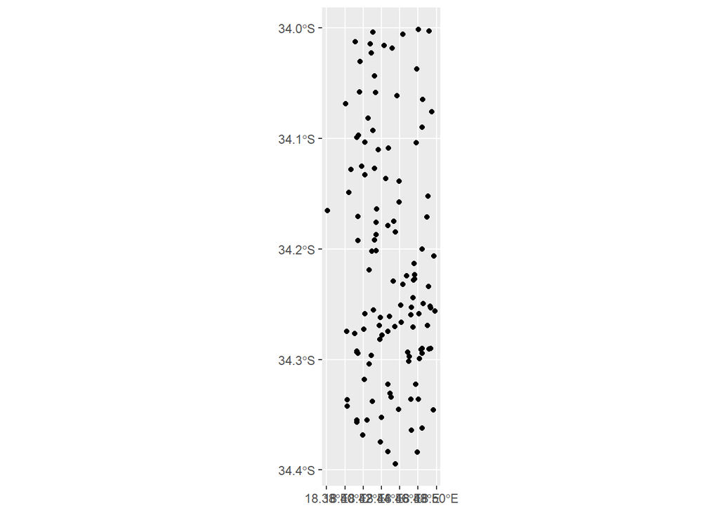

```r
install.packages("ggplot2")
library(ggplot2)
ggplot() + geom_sf(data=ssHe)
```

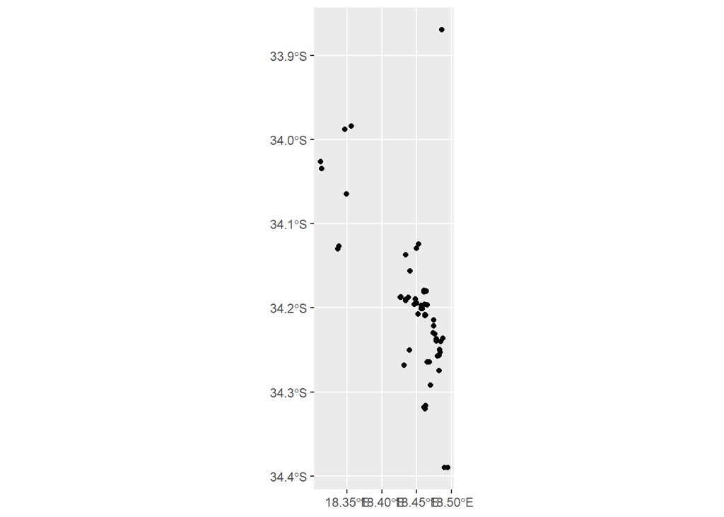

```r
ggplot() + geom_sf(data=ssHp)
```

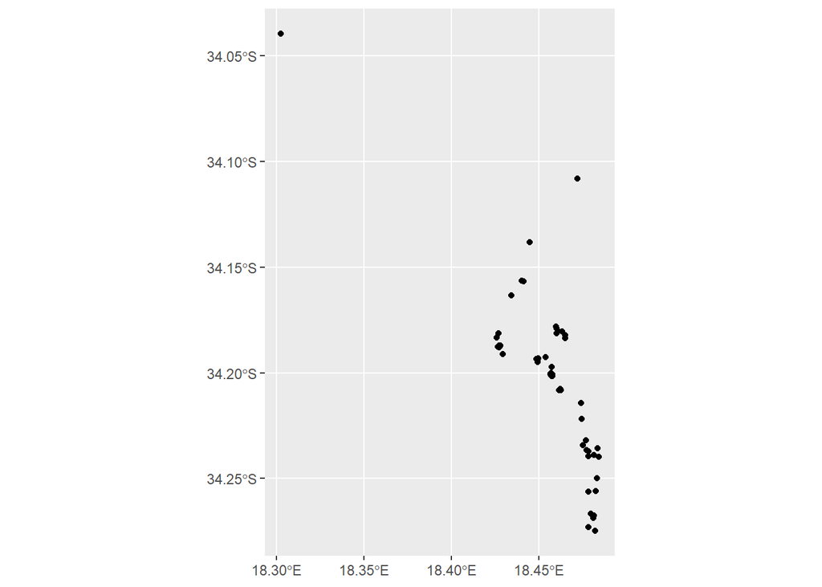

```r
ggplot() + geom_sf(data=ssPa)
```

Now plotting them with a base layer. This base layer will put a map behind the data to show where exactly the data points lie within the Cape Peninsula.

```r
library(rosm)
library(ggspatial)
```

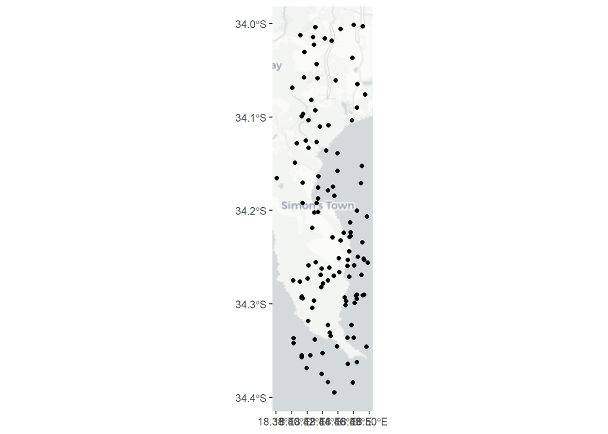

```r
ggplot() +
  annotation_map_tile(type = "cartolight", progress = "none") +
  geom_sf(data=ssHe)
```

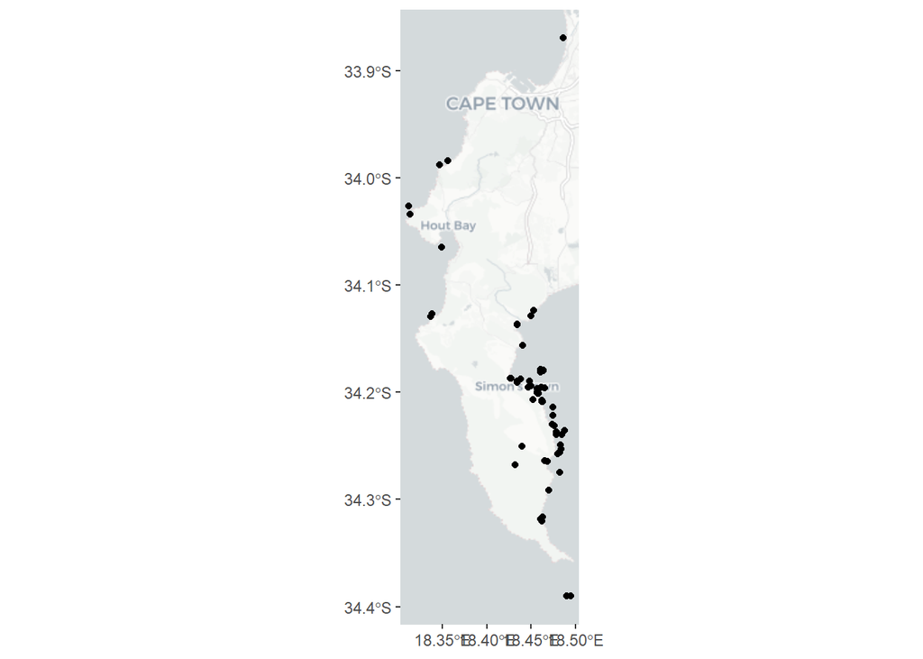

```r
ggplot() +
  annotation_map_tile(type = "cartolight", progress = "none") +
  geom_sf(data=ssHp)
```

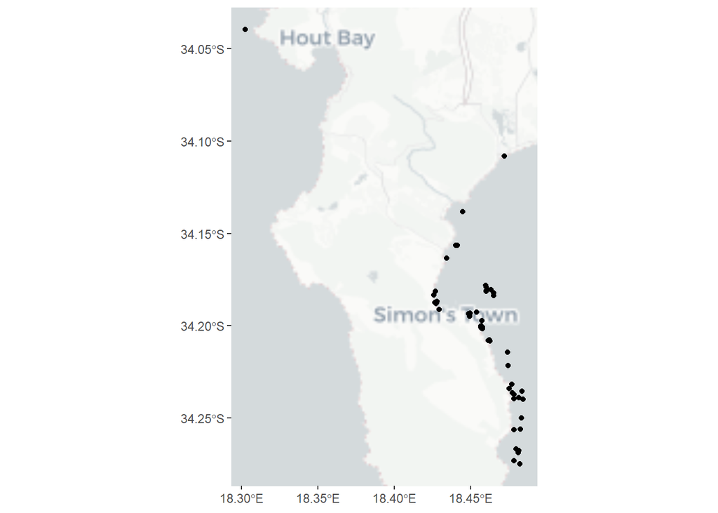

```r
ggplot() +
  annotation_map_tile(type = "cartolight", progress = "none") +
  geom_sf(data=ssPa)
```

## Creating Interactive Maps

Using leaflet and htmltools, we will now create interactive maps for all three species. With these maps we can zoom in and out to see the exact location of the sharks.

```r
library(leaflet)
library(htmltools)
```

```r
leaflet() %>%
  # Add default OpenStreetMap map tiles
  addTiles(group = "Default") %>%
  # Add our points
  addCircleMarkers(data = ssHe,
                   group = "Haploblepharus edwardsii",
                   radius = 3,
                   color = "blue")
```

[interactive chart not shown]

```r
leaflet() %>%
  addTiles(group = "Default") %>%
  addCircleMarkers(data = ssHp,
                   group = "Haploblepharus pictus",
                   radius = 3,
                   color = "blue")
```

[interactive chart not shown]

```r
leaflet() %>%
  addTiles(group = "Default") %>%
  addCircleMarkers(data = ssPa,
                   group = "Haploblepharus pictus",
                   radius = 3,
                   color = "blue")
```

[interactive chart not shown]

## Doing common sense checks

This step is to check if all the data points on the maps are research grade and not from someones back yard. In this case, the data on Haploblepharus edwardsii shows that there are sharks on land, however, this is an iNaturalist error and not one from the coding. I double checked this by clicking the link of a data point and seeing if it was in the same location as on my interactive map. Because they were in the same place on both iNaturalist and my map, it means that the iNaturalist data on location of the sharks is skewed slightly.

```r
library(mapview)
library(leafpop)
mapview(ssHe,
        popup =
          popupTable(ssHe,
                     zcol = c("user_login", "captive_cultivated", "url")))
```

[interactive chart not shown]

```r
mapview(ssHp,
        popup =
          popupTable(ssHp,
                     zcol = c("user_login", "captive_cultivated", "url")))
```

[interactive chart not shown]

```r
mapview(ssPa,
        popup =
          popupTable(ssPa,
                     zcol = c("user_login", "captive_cultivated", "url")))
```

[interactive chart not shown]

## Adding URL to the data points

In order for the map to be more interactive. Adding the URL to the data points is a good way to access the observational data directly.

```r
install.packages("dplyr")  # Only run if you haven't installed it yet
```

```r
library(dplyr)

lssHe <- ssHe %>%
  mutate(click_url = paste("<b><a href='", url, "'>Link to iNat observation</a></b>"))

mapview(ssHe,
        popup =
          popupTable(lssHe,
                     zcol = c("user_login", "captive_cultivated", "click_url")))
```

[interactive chart not shown]

```r
lssHp <- ssHp %>%
  mutate(click_url = paste("<b><a href='", url, "'>Link to iNat observation</a></b>"))

mapview(ssHp,
        popup =
          popupTable(lssHp,
                     zcol = c("user_login", "captive_cultivated", "click_url")))
```

[interactive chart not shown]

```r
lssPa <- ssPa %>%
  mutate(click_url = paste("<b><a href='", url, "'>Link to iNat observation</a></b>"))

mapview(ssPa,
        popup =
          popupTable(lssPa,
                     zcol = c("user_login", "captive_cultivated", "click_url")))
```

[interactive chart not shown]

## Extracting Coordinates from the Geometry Column

In order to plot all three species on the same interactive map, I need to extract the coordinates and add them as new columns in the data frame. I then checked the first 6 lines of code to see if R ran this correctly.

```r
library(sf)
ssHe_coords <- st_coordinates(ssHe)
# Add longitude and latitude as new columns to the dataframe
ssHe$longitude <- ssHe_coords[, 1]
ssHe$latitude <- ssHe_coords[, 2]

# Check the data
head(ssHe)
```

```
## Simple feature collection with 6 features and 37 fields
## Geometry type: POINT
## Dimension:     XY
## Bounding box:  xmin: 18.40197 ymin: -34.27802 xmax: 18.49373 ymax: -34.22826
## Geodetic CRS:  WGS 84
##            scientific_name                  datetime description
## 1 Haploblepharus edwardsii 2024-10-17 18:45:00 +0200
## 2 Haploblepharus edwardsii 2024-09-29 18:47:00 +0200
## 3 Haploblepharus edwardsii 2024-09-29 18:42:00 +0200
## 4 Haploblepharus edwardsii 2024-09-29 18:39:00 +0200
## 5 Haploblepharus edwardsii 2024-12-07 10:56:00 +0200
## 6 Haploblepharus edwardsii 2024-12-06 00:00:00 +0200
##        place_guess tag_list        common_name
## 1 Western Cape, ZA          Puffadder Shyshark
## 2 Western Cape, ZA          Puffadder Shyshark
```

[output cut: 74 more lines]

```r
#same as above lines of code but for the other two species
ssHp_coords <- st_coordinates(ssHp)
ssHp$longitude <- ssHp_coords[, 1]
ssHp$latitude <- ssHp_coords[, 2]


ssPa_coords <- st_coordinates(ssPa)
ssPa$longitude <- ssPa_coords[, 1]
ssPa$latitude <- ssPa_coords[, 2]
```

## Creating the three species interactive map

Similarly to the first time I created an interactive map, I used the same process for this but I continued adding addCircleMarkers() to make the interactive map more than one species.

```r
library(leaflet)

leaflet() %>%
  addTiles() %>%
  addCircleMarkers(data = ssHe,
                   ~longitude, ~latitude,
                   color = "blue",
                   radius = 3,
                   popup = ~paste("<b>Species:</b>", "Haploblepharus edwardsii",
                                  "<br><b>User:</b>", user_login,
                                  "<br><b>Cultivated:</b>", captive_cultivated,
                                  "<br><a href='", url, "'>Link to observation</a>"),
                   group = "Haploblepharus edwardsii") %>%
  addCircleMarkers(data = ssHp,
                   ~longitude, ~latitude,
                   color = "green",
                   radius = 3,
                   popup = ~paste("<b>Species:</b>", "Haploblepharus pictus",
                                  "<br><b>User:</b>", user_login,
                                  "<br><b>Cultivated:</b>", captive_cultivated,
                                  "<br><a href='", url, "'>Link to observation</a>"),
                   group = "Haploblepharus pictus") %>%
  addCircleMarkers(data = ssPa,
                   ~longitude, ~latitude,
                   color = "pink",
                   radius = 3,
                   popup = ~paste("<b>Species:</b>", "Poroderma africanum",
                                  "<br><b>User:</b>", user_login,
                                  "<br><b>Cultivated:</b>", captive_cultivated,
                                  "<br><a href='", url, "'>Link to observation</a>"),
                   group = "Poroderma africanum") %>%

  # Add layer control to switch between species
  addLayersControl(
    overlayGroups = c("Haploblepharus edwardsii", "Haploblepharus pictus", "Poroderma africanum"),
    options = layersControlOptions(collapsed = FALSE)
  )
```

[interactive chart not shown]

Now I have an interactive map with all three species distributions on it. This will allow me to plan my dive sites for data collection when I start collecting my own data for my honours project.